# Exploratory Data Analysis on Worldwide Vaccine Data

## What is Exploratory Data Analysis ?

Exploratory Data Analysis refers to the critical process of performing initial investigations on data so as to discover patterns,to spot anomalies,to test hypothesis and to check assumptions with the help of summary statistics and graphical representations.

We are performing EDA on the Worldwide Vaccine Data taken from the kaggle repository.

## Importing the Dataset

```r
df<-read.csv("C:/Users/Kabir Anna/Desktop/Worldwide Vaccine Data.csv")
head(df)
```

```
##       Country Doses.administered.per.100.people Total.doses.administered
## 1 Afghanistan                               3.6                  1381416
## 2     Albania                              42.0                  1203087
## 3     Algeria                               7.9                  3421279
## 4      Angola                               5.0                  1592537
## 5   Argentina                              72.0                 32335391
## 6     Armenia                               5.8                   171890
##   X..of.population.vaccinated X..of.population.fully.vaccinated
## 1                         2.0                               0.6
## 2                        24.0                              19.0
## 3                         7.9                               1.7
## 4                         3.0                               2.0
## 5                        56.0                              16.0
## 6                         4.1                               1.7
```

## The type of object can be ascertained using the class() command

```r
class(df)
```

```
## [1] "data.frame"
```

```r
class(df$Country)
```

```
## [1] "character"
```

```r
class(df$Doses.administered.per.100.people)
```

```
## [1] "numeric"
```

```r
class(dimnames(df))
```

```
## [1] "list"
```

## Shows the top of the data and by default shows the first six rows

```r
head(df)
```

```
##       Country Doses.administered.per.100.people Total.doses.administered
## 1 Afghanistan                               3.6                  1381416
## 2     Albania                              42.0                  1203087
## 3     Algeria                               7.9                  3421279
## 4      Angola                               5.0                  1592537
## 5   Argentina                              72.0                 32335391
## 6     Armenia                               5.8                   171890
##   X..of.population.vaccinated X..of.population.fully.vaccinated
## 1                         2.0                               0.6
## 2                        24.0                              19.0
## 3                         7.9                               1.7
## 4                         3.0                               2.0
## 5                        56.0                              16.0
## 6                         4.1                               1.7
```

## Can elect to show a different numberof rows using the n= instruction like so:

```r
head(df,n=3)
```

```
##       Country Doses.administered.per.100.people Total.doses.administered
## 1 Afghanistan                               3.6                  1381416
## 2     Albania                              42.0                  1203087
## 3     Algeria                               7.9                  3421279
##   X..of.population.vaccinated X..of.population.fully.vaccinated
## 1                         2.0                               0.6
## 2                        24.0                              19.0
## 3                         7.9                               1.7
```

## can also display the bottom of the data using the tail() command default shows the last six rows:

```r
tail(df)
```

```
##              Country Doses.administered.per.100.people Total.doses.administered
## 173        Venezuela                              14.0                  4000000
## 174          Vietnam                               7.2                  6959197
## 175 West Bank & Gaza                              22.0                  1007483
## 176            Yemen                               1.1                   311483
## 177           Zambia                               2.5                   441113
## 178         Zimbabwe                              17.0                  2433341
##     X..of.population.vaccinated X..of.population.fully.vaccinated
## 173                        10.0                               3.9
## 174                         6.5                               0.7
## 175                        13.0                               8.9
## 176                         1.0                               0.1
## 177                         1.6                               0.9
## 178                        11.0                               5.3
```

## Can elect to show a differnet number of rows usin g the n= instruction like so:

```r
tail(df,n=3)
```

```
##      Country Doses.administered.per.100.people Total.doses.administered
## 176    Yemen                               1.1                   311483
## 177   Zambia                               2.5                   441113
## 178 Zimbabwe                              17.0                  2433341
##     X..of.population.vaccinated X..of.population.fully.vaccinated
## 176                         1.0                               0.1
## 177                         1.6                               0.9
## 178                        11.0                               5.3
```

## Changing the NA or missing values to the zero

```r
df1=df
df1[is.na(df1)]=0
head(df1)
```

```
##       Country Doses.administered.per.100.people Total.doses.administered
## 1 Afghanistan                               3.6                  1381416
## 2     Albania                              42.0                  1203087
## 3     Algeria                               7.9                  3421279
## 4      Angola                               5.0                  1592537
## 5   Argentina                              72.0                 32335391
## 6     Armenia                               5.8                   171890
##   X..of.population.vaccinated X..of.population.fully.vaccinated
## 1                         2.0                               0.6
## 2                        24.0                              19.0
## 3                         7.9                               1.7
## 4                         3.0                               2.0
## 5                        56.0                              16.0
## 6                         4.1                               1.7
```

## To get information about an Data frame and particular columns:

```r
summary(df)
```

```
##    Country          Doses.administered.per.100.people Total.doses.administered
##  Length:178         Min.   :  0.10                    Min.   :6.576e+03
##  Class :character   1st Qu.:  7.00                    1st Qu.:3.319e+05
##  Mode  :character   Median : 38.00                    Median :1.759e+06
##                     Mean   : 48.69                    Mean   :2.370e+07
##                     3rd Qu.: 82.00                    3rd Qu.:9.413e+06
##                     Max.   :172.00                    Max.   :1.689e+09
##                     NA's   :1                         NA's   :1
##  X..of.population.vaccinated X..of.population.fully.vaccinated
##  Min.   : 0.10               Min.   : 0.10
##  1st Qu.: 5.30               1st Qu.: 2.00
##  Median :25.00               Median :14.00
##  Mean   :28.97               Mean   :20.59
##  3rd Qu.:48.50               3rd Qu.:36.25
##  Max.   :80.00               Max.   :76.00
##  NA's   :3                   NA's   :6
```

```r
summary(df$Country)
```

```
##    Length     Class      Mode
##       178 character character
```

```r
summary(df$Doses.administered.per.100.people)
```

```
##    Min. 1st Qu.  Median    Mean 3rd Qu.    Max.    NA's
##    0.10    7.00   38.00   48.69   82.00  172.00       1
```

```r
mean(df1$Doses.administered.per.100.people)
```

```
## [1] 48.41629
```

```r
mean(df1$Total.doses.administered)
```

```
## [1] 23568722
```

```r
mean(df1$X..of.population.vaccinated)
```

```
## [1] 28.48315
```

```r
mean(df1$X..of.population.fully.vaccinated)
```

```
## [1] 19.89831
```

```r
sum(df1$Doses.administered.per.100.people)
```

```
## [1] 8618.1
```

```r
median(df1$Doses.administered.per.100.people)
```

```
## [1] 37
```

```r
median(df1$Total.doses.administered)
```

```
## [1] 1747428
```

```r
median(df1$X..of.population.vaccinated)
```

```
## [1] 25
```

```r
median(df1$X..of.population.fully.vaccinated)
```

```
## [1] 12.5
```

```r
median(df1$Doses.administered.per.100.people)
```

```
## [1] 37
```

```r
median(df1$Total.doses.administered)
```

```
## [1] 1747428
```

```r
median(df1$X..of.population.vaccinated)
```

```
## [1] 25
```

```r
median(df1$X..of.population.fully.vaccinated)
```

```
## [1] 12.5
```

```r
mode(df1$Country)
```

```
## [1] "character"
```

```r
mode(df1$Doses.administered.per.100.people)
```

```
## [1] "numeric"
```

```r
mode(df1$Total.doses.administered)
```

```
## [1] "numeric"
```

```r
var(df1$Doses.administered.per.100.people)
```

```
## [1] 2007.975
```

```r
var(df1$Total.doses.administered)
```

```
## [1] 1.800381e+16
```

```r
var(df1$X..of.population.vaccinated)
```

```
## [1] 596.3269
```

```r
var(df1$X..of.population.fully.vaccinated)
```

```
## [1] 451.2345
```

```r
sd(df1$Doses.administered.per.100.people)
```

```
## [1] 44.81043
```

```r
quantile(df1$Total.doses.administered)
```

```
##         0%        25%        50%        75%       100%
##          0     316581    1747428    9376739 1688683000
```

## Returns Tukey’s five number summary (min,lower hinge,median,upper hinge,max) for the input data.

```r
fivenum(df$Doses.administered.per.100.people)
```

```
## [1]   0.1   7.0  38.0  82.0 172.0
```

```r
cov(df1$Doses.administered.per.100.people,df1$Total.doses.administered)
```

```
## [1] 1057789362
```

## F Test to compare two variances

```r
var.test(df1$Doses.administered.per.100.people,df1$Total.doses.administered)
```

```
##
##  F test to compare two variances
##
## data:  df1$Doses.administered.per.100.people and df1$Total.doses.administered
## F = 1.1153e-13, num df = 177, denom df = 177, p-value < 2.2e-16
## alternative hypothesis: true ratio of variances is not equal to 1
## 95 percent confidence interval:
##  8.298896e-14 1.498882e-13
## sample estimates:
## ratio of variances
##       1.115305e-13
```

## str() command is useful to see the objective structure

```r
str(df)
```

```
## 'data.frame':    178 obs. of  5 variables:
##  $ Country                          : chr  "Afghanistan" "Albania" "Algeria" "Angola" ...
##  $ Doses.administered.per.100.people: num  3.6 42 7.9 5 72 5.8 130 49 110 50 ...
##  $ Total.doses.administered         : num  1381416 1203087 3421279 1592537 32335391 ...
##  $ X..of.population.vaccinated      : num  2 24 7.9 3 56 4.1 68 33 60 29 ...
##  $ X..of.population.fully.vaccinated: num  0.6 19 1.7 2 16 1.7 62 15 52 21 ...
```

## structure returns the given object with further attributes set

```r
head(structure(df))
```

```
##       Country Doses.administered.per.100.people Total.doses.administered
## 1 Afghanistan                               3.6                  1381416
## 2     Albania                              42.0                  1203087
## 3     Algeria                               7.9                  3421279
## 4      Angola                               5.0                  1592537
## 5   Argentina                              72.0                 32335391
## 6     Armenia                               5.8                   171890
##   X..of.population.vaccinated X..of.population.fully.vaccinated
## 1                         2.0                               0.6
## 2                        24.0                              19.0
## 3                         7.9                               1.7
## 4                         3.0                               2.0
## 5                        56.0                              16.0
## 6                         4.1                               1.7
```

## can also look at all the named objects you have at ince using the ls.str() command

```r
ls.str(df)
```

```
## Country :  chr [1:178] "Afghanistan" "Albania" "Algeria" "Angola" "Argentina" ...
## Doses.administered.per.100.people :  num [1:178] 3.6 42 7.9 5 72 5.8 130 49 110 50 ...
## Total.doses.administered :  num [1:178] 1381416 1203087 3421279 1592537 32335391 ...
## X..of.population.fully.vaccinated :  num [1:178] 0.6 19 1.7 2 16 1.7 62 15 52 21 ...
## X..of.population.vaccinated :  num [1:178] 2 24 7.9 3 56 4.1 68 33 60 29 ...
```

## can use the pattern instructin to narrow down your focus

```r
ls.str(pattern ='df')
```

```
## df : 'data.frame':   178 obs. of  5 variables:
##  $ Country                          : chr  "Afghanistan" "Albania" "Algeria" "Angola" ...
##  $ Doses.administered.per.100.people: num  3.6 42 7.9 5 72 5.8 130 49 110 50 ...
##  $ Total.doses.administered         : num  1381416 1203087 3421279 1592537 32335391 ...
##  $ X..of.population.vaccinated      : num  2 24 7.9 3 56 4.1 68 33 60 29 ...
##  $ X..of.population.fully.vaccinated: num  0.6 19 1.7 2 16 1.7 62 15 52 21 ...
## df1 : 'data.frame':  178 obs. of  5 variables:
##  $ Country                          : chr  "Afghanistan" "Albania" "Algeria" "Angola" ...
##  $ Doses.administered.per.100.people: num  3.6 42 7.9 5 72 5.8 130 49 110 50 ...
##  $ Total.doses.administered         : num  1381416 1203087 3421279 1592537 32335391 ...
##  $ X..of.population.vaccinated      : num  2 24 7.9 3 56 4.1 68 33 60 29 ...
##  $ X..of.population.fully.vaccinated: num  0.6 19 1.7 2 16 1.7 62 15 52 21 ...
```

## The most basic command that enables the viewing of the column or row is:

```r
names(df)
```

```
## [1] "Country"                           "Doses.administered.per.100.people"
## [3] "Total.doses.administered"          "X..of.population.vaccinated"
## [5] "X..of.population.fully.vaccinated"
```

```r
row.names(df)
```

```
##   [1] "1"   "2"   "3"   "4"   "5"   "6"   "7"   "8"   "9"   "10"  "11"  "12"
##  [13] "13"  "14"  "15"  "16"  "17"  "18"  "19"  "20"  "21"  "22"  "23"  "24"
##  [25] "25"  "26"  "27"  "28"  "29"  "30"  "31"  "32"  "33"  "34"  "35"  "36"
##  [37] "37"  "38"  "39"  "40"  "41"  "42"  "43"  "44"  "45"  "46"  "47"  "48"
##  [49] "49"  "50"  "51"  "52"  "53"  "54"  "55"  "56"  "57"  "58"  "59"  "60"
##  [61] "61"  "62"  "63"  "64"  "65"  "66"  "67"  "68"  "69"  "70"  "71"  "72"
##  [73] "73"  "74"  "75"  "76"  "77"  "78"  "79"  "80"  "81"  "82"  "83"  "84"
##  [85] "85"  "86"  "87"  "88"  "89"  "90"  "91"  "92"  "93"  "94"  "95"  "96"
##  [97] "97"  "98"  "99"  "100" "101" "102" "103" "104" "105" "106" "107" "108"
## [109] "109" "110" "111" "112" "113" "114" "115" "116" "117" "118" "119" "120"
## [121] "121" "122" "123" "124" "125" "126" "127" "128" "129" "130" "131" "132"
## [133] "133" "134" "135" "136" "137" "138" "139" "140" "141" "142" "143" "144"
## [145] "145" "146" "147" "148" "149" "150" "151" "152" "153" "154" "155" "156"
## [157] "157" "158" "159" "160" "161" "162" "163" "164" "165" "166" "167" "168"
## [169] "169" "170" "171" "172" "173" "174" "175" "176" "177" "178"
```

```r
colnames(df)
```

```
## [1] "Country"                           "Doses.administered.per.100.people"
## [3] "Total.doses.administered"          "X..of.population.vaccinated"
## [5] "X..of.population.fully.vaccinated"
```

```r
dimnames(df)
```

```
## [[1]]
##   [1] "1"   "2"   "3"   "4"   "5"   "6"   "7"   "8"   "9"   "10"  "11"  "12"
##  [13] "13"  "14"  "15"  "16"  "17"  "18"  "19"  "20"  "21"  "22"  "23"  "24"
##  [25] "25"  "26"  "27"  "28"  "29"  "30"  "31"  "32"  "33"  "34"  "35"  "36"
##  [37] "37"  "38"  "39"  "40"  "41"  "42"  "43"  "44"  "45"  "46"  "47"  "48"
##  [49] "49"  "50"  "51"  "52"  "53"  "54"  "55"  "56"  "57"  "58"  "59"  "60"
##  [61] "61"  "62"  "63"  "64"  "65"  "66"  "67"  "68"  "69"  "70"  "71"  "72"
##  [73] "73"  "74"  "75"  "76"  "77"  "78"  "79"  "80"  "81"  "82"  "83"  "84"
##  [85] "85"  "86"  "87"  "88"  "89"  "90"  "91"  "92"  "93"  "94"  "95"  "96"
##  [97] "97"  "98"  "99"  "100" "101" "102" "103" "104" "105" "106" "107" "108"
## [109] "109" "110" "111" "112" "113" "114" "115" "116" "117" "118" "119" "120"
## [121] "121" "122" "123" "124" "125" "126" "127" "128" "129" "130" "131" "132"
## [133] "133" "134" "135" "136" "137" "138" "139" "140" "141" "142" "143" "144"
## [145] "145" "146" "147" "148" "149" "150" "151" "152" "153" "154" "155" "156"
## [157] "157" "158" "159" "160" "161" "162" "163" "164" "165" "166" "167" "168"
## [169] "169" "170" "171" "172" "173" "174" "175" "176" "177" "178"
##
## [[2]]
## [1] "Country"                           "Doses.administered.per.100.people"
## [3] "Total.doses.administered"          "X..of.population.vaccinated"
## [5] "X..of.population.fully.vaccinated"
```

```r
dim(df)
```

```
## [1] 178   5
```

```r
nrow(df)
```

```
## [1] 178
```

```r
ncol(df)
```

```
## [1] 5
```

```r
sin(head(df1$Doses.administered.per.100.people))
```

```
## [1] -0.4425204 -0.9165215  0.9989413 -0.9589243  0.2538234 -0.4646022
```

```r
cos(head(df1$Doses.administered.per.100.people))
```

```
## [1] -0.89675842 -0.39998531 -0.04600213  0.28366219 -0.96725059  0.88551952
```

```r
factorial(head(df1$Doses.administered.per.100.people))
```

```
## [1]  1.338129e+01  1.405006e+51  3.256940e+04  1.200000e+02 6.123446e+103
## [6]  4.966061e+02
```

```r
abs(head(df1$Doses.administered.per.100.people))
```

```
## [1]  3.6 42.0  7.9  5.0 72.0  5.8
```

```r
sqrt(head(df1$Doses.administered.per.100.people))
```

```
## [1] 1.897367 6.480741 2.810694 2.236068 8.485281 2.408319
```

```r
tan(head(df1$Doses.administered.per.100.people))
```

```
## [1]   0.4934667   2.2913880 -21.7151127  -3.3805150  -0.2624174  -0.5246662
```

```r
asin(head(df1$Doses.administered.per.100.people))
```

```
## [1] NaN NaN NaN NaN NaN NaN
```

## Accessing the rows or columns

```r
head(df1[1])
```

```
##       Country
## 1 Afghanistan
## 2     Albania
## 3     Algeria
## 4      Angola
## 5   Argentina
## 6     Armenia
```

```r
head(df1[1:4])
```

```
##       Country Doses.administered.per.100.people Total.doses.administered
## 1 Afghanistan                               3.6                  1381416
## 2     Albania                              42.0                  1203087
## 3     Algeria                               7.9                  3421279
## 4      Angola                               5.0                  1592537
## 5   Argentina                              72.0                 32335391
## 6     Armenia                               5.8                   171890
##   X..of.population.vaccinated
## 1                         2.0
## 2                        24.0
## 3                         7.9
## 4                         3.0
## 5                        56.0
## 6                         4.1
```

```r
head(df1[-1])
```

```
##   Doses.administered.per.100.people Total.doses.administered
## 1                               3.6                  1381416
## 2                              42.0                  1203087
## 3                               7.9                  3421279
## 4                               5.0                  1592537
## 5                              72.0                 32335391
## 6                               5.8                   171890
##   X..of.population.vaccinated X..of.population.fully.vaccinated
## 1                         2.0                               0.6
## 2                        24.0                              19.0
## 3                         7.9                               1.7
## 4                         3.0                               2.0
## 5                        56.0                              16.0
## 6                         4.1                               1.7
```

```r
head(df1[df1 > 7])
```

```
## [1] "Afghanistan" "Albania"     "Algeria"     "Angola"      "Argentina"
## [6] "Armenia"
```

```r
head(df1[df1 < 5 | df1 > 10], n = 10)
```

```
##  [1] "Afghanistan" "Albania"     "Algeria"     "Angola"      "Argentina"
##  [6] "Armenia"     "Aruba"       "Australia"   "Austria"     "Azerbaijan"
```

## length() command used to determine the number of items in an object

```r
length(df)
```

```
## [1] 5
```

```r
length(df$Doses.administered.per.100.people)
```

```
## [1] 178
```

```r
length(df$Total.doses.administered)
```

```
## [1] 178
```

```r
length(df$X..of.population.vaccinated)
```

```
## [1] 178
```

```r
length(df$X..of.population.fully.vaccinated)
```

```
## [1] 178
```

## To extract a particulafr column and particular row values

```r
head(df$Total.doses.administered)
```

```
## [1]  1381416  1203087  3421279  1592537 32335391   171890
```

```r
df$Total.doses.administered[3]
```

```
## [1] 3421279
```

```r
df$Total.doses.administered[1:5]
```

```
## [1]  1381416  1203087  3421279  1592537 32335391
```

```r
tdf = attach(df)
tdf
```

```
## <environment: 0x0000000014e91c28>
## attr(,"name")
## [1] "df"
```

## The max() and min() commands display the largest and smallest values in a numeric object

```r
max(df1$Doses.administered.per.100.people)
```

```
## [1] 172
```

```r
max(df1$X..of.population.vaccinated)
```

```
## [1] 80
```

```r
min(df1$Total.doses.administered)
```

```
## [1] 0
```

```r
min(df1$X..of.population.vaccinated)
```

```
## [1] 0
```

```r
head(stack(df))
```

```
##        values     ind
## 1 Afghanistan Country
## 2     Albania Country
## 3     Algeria Country
## 4      Angola Country
## 5   Argentina Country
## 6     Armenia Country
```

## Sorting default is ascending order

```r
head(sort(df$Total.doses.administered))
```

```
## [1]  6576 23995 25225 25635 29980 36524
```

```r
head(sort(df$Doses.administered.per.100.people))
```

```
## [1] 0.1 0.1 0.2 0.2 0.5 0.5
```

## can get an index using the order() command

```r
head(order(df$Doses.administered.per.100.people))
```

```
## [1]  36  67  26  32  18 148
```

```r
head(order(df$Total.doses.administered))
```

```
## [1]  67 172  65 134  32  62
```

```r
head(rank(df$Doses.administered.per.100.people),n=10)
```

```
##  [1]  29.0  94.5  47.0  35.0 126.0  42.0 168.5 103.5 150.5 106.5
```

## Displaying selected rows and columns

```r
df[3,1]
```

```
## [1] "Algeria"
```

```r
df[1]
```

```
##                              Country
## 1                        Afghanistan
## 2                            Albania
## 3                            Algeria
## 4                             Angola
## 5                          Argentina
## 6                            Armenia
## 7                              Aruba
## 8                          Australia
## 9                            Austria
## 10                        Azerbaijan
## 11                           Bahamas
## 12                           Bahrain
## 13                        Bangladesh
## 14                          Barbados
```

[output cut: 164 more lines]

## To convert from data frame from matrix

```r
head(as.matrix(df))
```

```
##      Country       Doses.administered.per.100.people Total.doses.administered
## [1,] "Afghanistan" "  3.6"                           "   1381416"
## [2,] "Albania"     " 42.0"                           "   1203087"
## [3,] "Algeria"     "  7.9"                           "   3421279"
## [4,] "Angola"      "  5.0"                           "   1592537"
## [5,] "Argentina"   " 72.0"                           "  32335391"
## [6,] "Armenia"     "  5.8"                           "    171890"
##      X..of.population.vaccinated X..of.population.fully.vaccinated
## [1,] " 2.0"                      " 0.6"
## [2,] "24.0"                      "19.0"
## [3,] " 7.9"                      " 1.7"
## [4,] " 3.0"                      " 2.0"
## [5,] "56.0"                      "16.0"
## [6,] " 4.1"                      " 1.7"
```

## The cbind() and rbind() commands assmeble a matrix/data frames by columns or rows,from several other object.

```r
head(rbind(df))
```

```
##       Country Doses.administered.per.100.people Total.doses.administered
## 1 Afghanistan                               3.6                  1381416
## 2     Albania                              42.0                  1203087
## 3     Algeria                               7.9                  3421279
## 4      Angola                               5.0                  1592537
## 5   Argentina                              72.0                 32335391
## 6     Armenia                               5.8                   171890
##   X..of.population.vaccinated X..of.population.fully.vaccinated
## 1                         2.0                               0.6
## 2                        24.0                              19.0
## 3                         7.9                               1.7
## 4                         3.0                               2.0
## 5                        56.0                              16.0
## 6                         4.1                               1.7
```

```r
head(cbind(df))
```

```
##       Country Doses.administered.per.100.people Total.doses.administered
## 1 Afghanistan                               3.6                  1381416
## 2     Albania                              42.0                  1203087
## 3     Algeria                               7.9                  3421279
## 4      Angola                               5.0                  1592537
## 5   Argentina                              72.0                 32335391
## 6     Armenia                               5.8                   171890
##   X..of.population.vaccinated X..of.population.fully.vaccinated
## 1                         2.0                               0.6
## 2                        24.0                              19.0
## 3                         7.9                               1.7
## 4                         3.0                               2.0
## 5                        56.0                              16.0
## 6                         4.1                               1.7
```

## simple cumulative commands

```r
head(cumsum(df$Doses.administered.per.100.people))
```

```
## [1]   3.6  45.6  53.5  58.5 130.5 136.3
```

```r
head(cummax(df$Doses.administered.per.100.people))
```

```
## [1]  3.6 42.0 42.0 42.0 72.0 72.0
```

```r
head(cummin(df$Doses.administered.per.100.people))
```

```
## [1] 3.6 3.6 3.6 3.6 3.6 3.6
```

```r
head(cumprod(df$Doses.administered.per.100.people))
```

```
## [1]       3.60     151.20    1194.48    5972.40  430012.80 2494074.24
```

## The table() command enablesyou to specify which columns of data yoy want to use to create your contigency table.

```r
table(df$Doses.administered.per.100.people)
```

```
##
## 0.1 0.2 0.5 0.8   1 1.1 1.3 1.6 1.8 1.9   2 2.3 2.5 2.6 2.8 2.9 3.2 3.3 3.4 3.6
##   2   2   2   1   2   1   2   1   1   3   3   1   1   1   1   1   1   1   1   1
## 3.7   4 4.2 4.3   5 5.1 5.3 5.6 5.7 5.8   6 6.4   7 7.2 7.9   8 8.1 8.3 8.5 9.3
##   1   2   1   1   1   1   2   2   1   1   1   1   1   1   1   1   1   1   1   1
##  10  12  13  14  15  17  19  20  22  23  25  26  27  28  29  30  31  33  35  36
##   1   1   3   3   2   2   2   2   2   4   1   2   1   1   3   1   1   1   2   1
##  38  39  40  42  43  45  46  47  49  50  52  53  54  55  57  58  61  63  66  67
##   2   1   2   2   3   1   1   2   2   4   1   1   1   1   1   1   2   1   1   1
##  68  71  72  75  76  78  80  81  82  83  86  87  89  91  94  96  98  99 101 103
##   3   3   1   1   1   2   1   1   1   2   1   1   1   2   1   1   1   1   1   2
## 105 110 111 114 115 119 121 123 126 127 128 129 130 132 134 135 139 142 151 172
##   2   2   3   1   2   2   2   1   1   2   1   1   2   1   1   2   1   1   1   1
```

```r
head(as.table(df$Doses.administered.per.100.people))
```

```
##    A    B    C    D    E    F
##  3.6 42.0  7.9  5.0 72.0  5.8
```

## The class() command can form the basis of a logical test by using the if() command in the following manner:

```r
if(class(df) == 'data.frame') TRUE else FALSE
```

```
## [1] TRUE
```

## TO check whether the data extracted is data frame or not

```r
is.data.frame(df)
```

```
## [1] TRUE
```

```r
is.table(df)
```

```
## [1] FALSE
```

## The seq_along() command creates a simple index

```r
seq_along(df)
```

```
## [1] 1 2 3 4 5
```

## create a basic stem and leaf plot using the stem() command

```r
stem(df$Doses.administered.per.100.people)
```

```
##
##   The decimal point is 1 digit(s) to the right of the |
##
##    0 | 0000111111112222222223333333444444555566666677888899
##    1 | 02333444557799
##    2 | 0022333356678999
##    3 | 013556889
##    4 | 0022333567799
##    5 | 0000234578
##    6 | 11367888
##    7 | 11125688
##    8 | 01233679
##    9 | 114689
##   10 | 13355
##   11 | 0011145599
##   12 | 11367789
##   13 | 0024559
##   14 | 2
##   15 | 1
##   16 |
##   17 | 2
```

## Now increase the number of bins used by adding a scale=2 instruction

```r
stem(df$Doses.administered.per.100.people, scale=2)
```

```
##
##   The decimal point is 1 digit(s) to the right of the |
##
##    0 | 0000111111112222222223333333444444
##    0 | 555566666677888899
##    1 | 02333444
##    1 | 557799
##    2 | 00223333
##    2 | 56678999
##    3 | 013
##    3 | 556889
##    4 | 0022333
##    4 | 567799
##    5 | 0000234
##    5 | 578
```

[output cut: 23 more lines]

## stem with a conditional statement:

```r
with(df, stem(df$Doses.administered.per.100.people[df$X..of.population.vaccinated >=25 ]))
```

```
##
##   The decimal point is 1 digit(s) to the right of the |
##
##    2 | 9055889
##    4 | 02333677990000234578
##    6 | 1136788811125688
##    8 | 01233679114689
##   10 | 133550011145599
##   12 | 13677890024559
##   14 | 21
##   16 | 2
```

## Histogram plotting

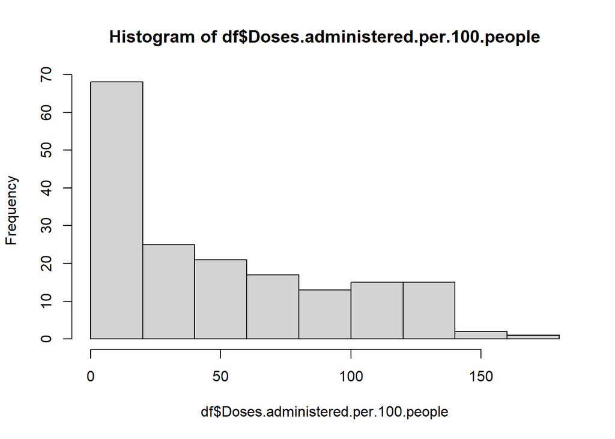

```r
hist(df$Doses.administered.per.100.people)
```

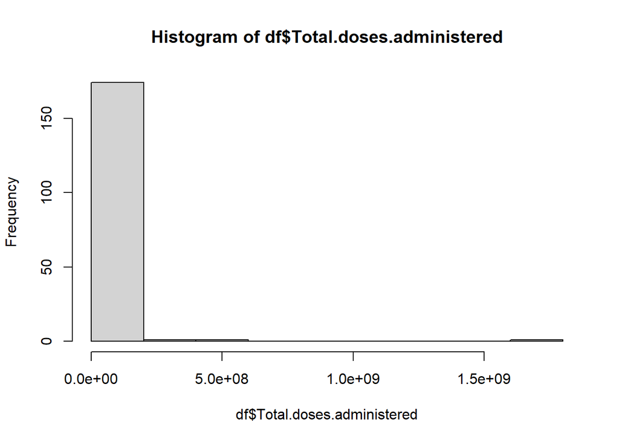

```r
hist(df$Total.doses.administered)
```

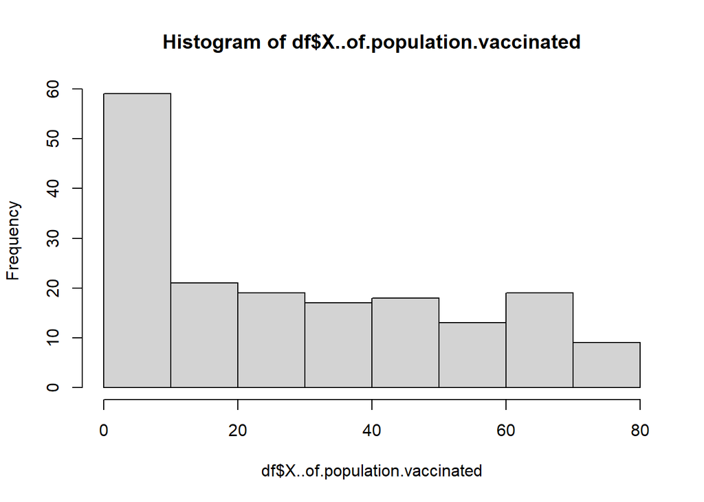

```r
hist(df$X..of.population.vaccinated)
```

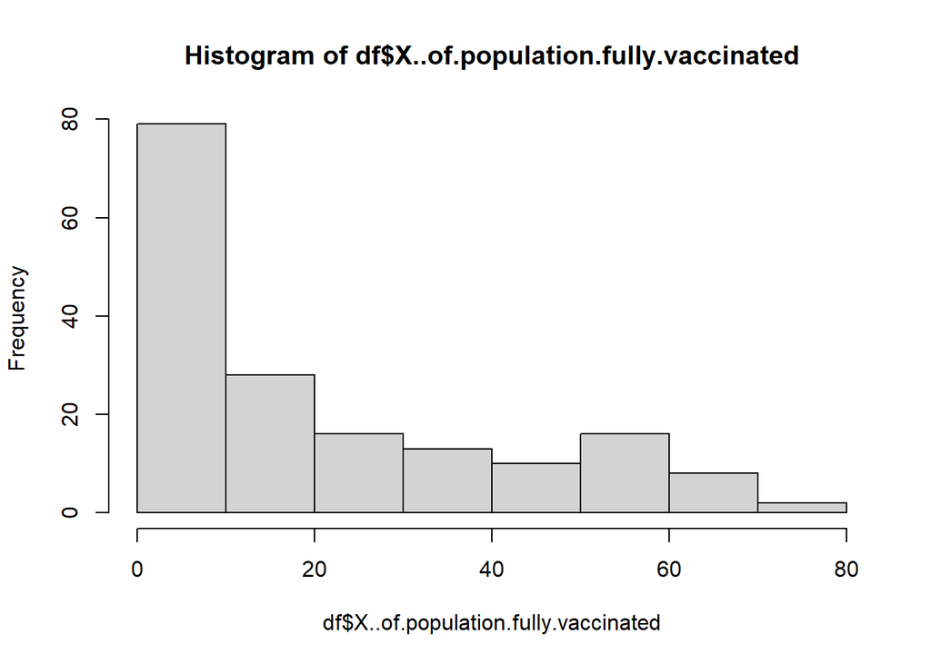

```r
hist(df$X..of.population.fully.vaccinated)
```

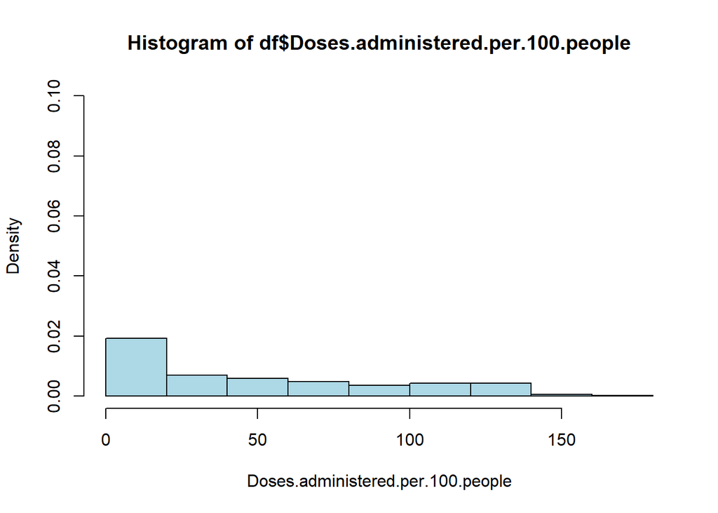

```r
hist(df$Doses.administered.per.100.people, col = 'lightblue', xlab = 'Doses.administered.per.100.people', ylim = c(0, 0.1), freq = FALSE)
```

## Have seen in drawing a histogram with the hist() command that you can use freq= FALSE to force the y-axis to display the densiy rather than the frequency of the data.You can also call on the density function directly via the density() command.

```r
density(df1$Doses.administered.per.100.people)
```

```
##
## Call:
##  density.default(x = df1$Doses.administered.per.100.people)
##
## Data: df1$Doses.administered.per.100.people (178 obs.);  Bandwidth 'bw' = 14.31
##
##        x                y
##  Min.   :-42.92   Min.   :1.773e-06
##  1st Qu.: 21.54   1st Qu.:4.991e-04
##  Median : 86.00   Median :3.985e-03
##  Mean   : 86.00   Mean   :3.874e-03
##  3rd Qu.:150.46   3rd Qu.:5.700e-03
##  Max.   :214.92   Max.   :1.142e-02
```

## using the density function to draw a graph

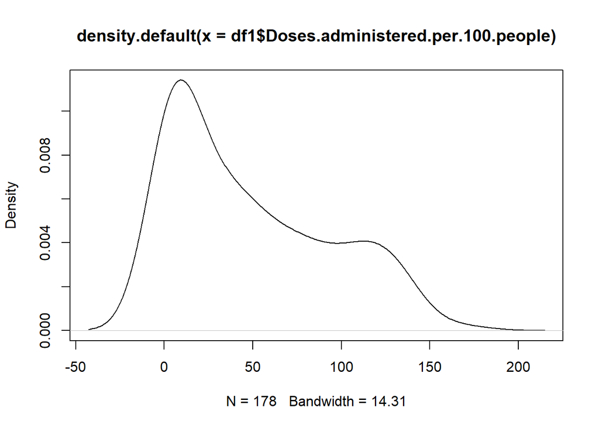

```r
plot(density(df1$Doses.administered.per.100.people))
```

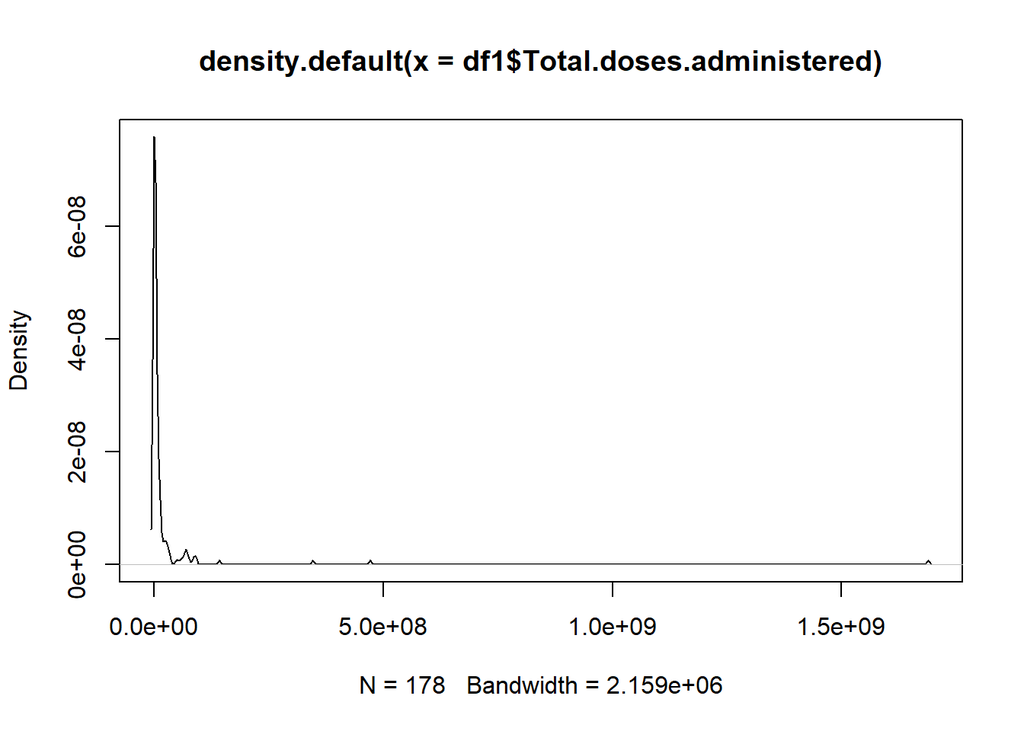

```r
plot(density(df1$Total.doses.administered))
```

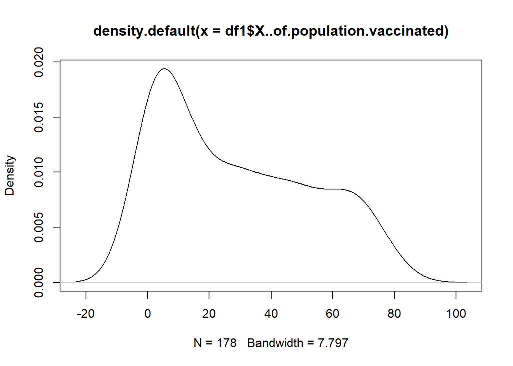

```r
plot(density(df1$X..of.population.vaccinated))
```

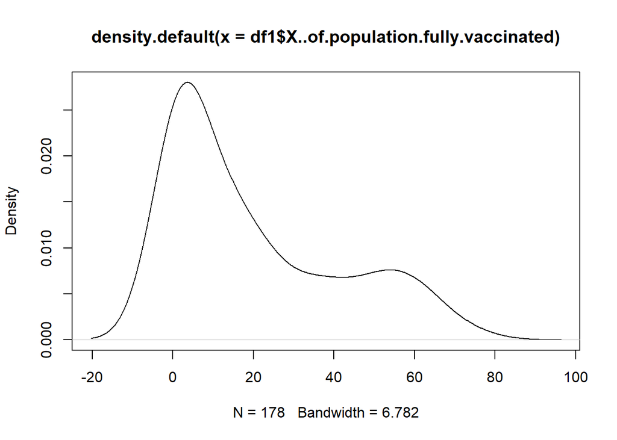

```r
plot(density(df1$X..of.population.fully.vaccinated))
```

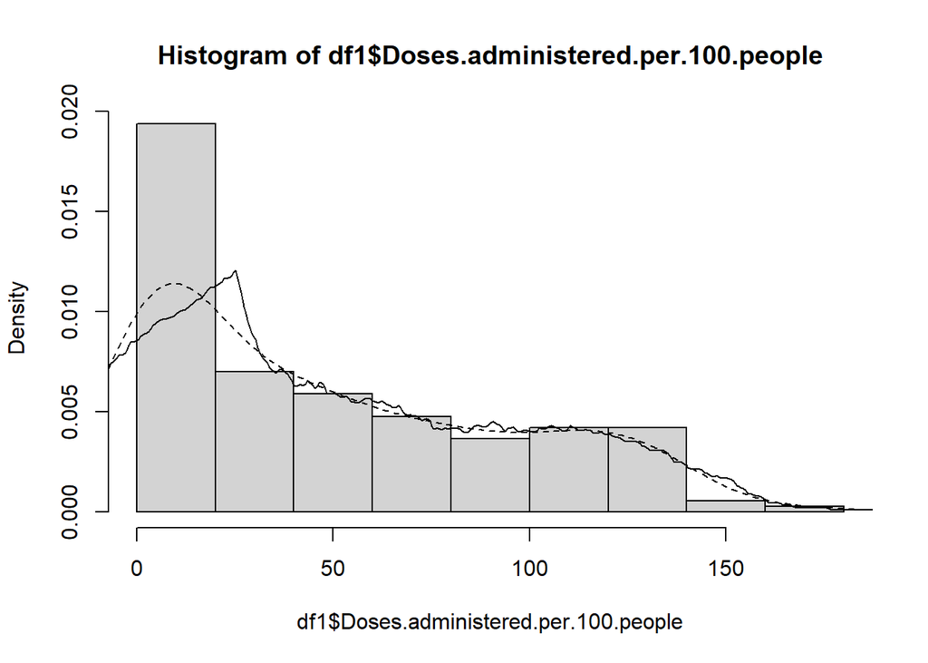

```r
hist(df1$Doses.administered.per.100.people, freq=F)
lines(density(df1$Doses.administered.per.100.people),lty=2)
lines(density(df1$Doses.administered.per.100.people, k='rectangular'))
```

## Random number and sampling

```r
sample(df$Doses.administered.per.100.people,size=4)
```

```
## [1] 49.0  8.1  5.3 17.0
```

```r
sample(df$Doses.administered.per.100.people,size=4,replace = TRUE)
```

```
## [1] 134 123  68  17
```

```r
sample(df1$Doses.administered.per.100.people[df1$Doses.administered.per.100.people<5.0])
```

```
##  [1] 2.3 4.3 1.0 3.6 3.7 4.0 0.1 0.1 0.5 1.9 0.2 2.5 0.5 3.4 4.0 2.0 1.8 1.3 3.3
## [20] 0.8 0.0 1.6 1.9 2.0 1.0 2.9 2.6 2.8 2.0 1.1 1.3 0.2 4.2 3.2 1.9
```

```r
sample(df1$Doses.administered.per.100.people[df1$Doses.administered.per.100.people>40.0])
```

```
##  [1]  71 121  43 111  43 151  46 111  94  42 119  50  49  55 132  66 134 103  78
## [20]  42  75  87  54  47  89 129 142  58 110  50 114 135  52  82  67 172  43 110
## [39]  71  50 126  61  68  86 119  91 139 127 115 130  71  91  61  63  83 121 101
## [58]  83  99 115  50 128 105  47  45  78  49 103 111 123  98 135  81 130  53  72
## [77]  57  80 105  68  96  68  76 127
```

## Generates n random numbers from the normal distribution with mean of 0 and standard deviation of 1

```r
head(rnorm(df$Doses.administered.per.100.people, mean=0 ,sd=1))
```

```
## [1] -1.16294535  0.08331734  0.14255590 -0.09292222  1.19496849 -0.82878372
```

## Returns the probability for the quantile q

```r
head(pnorm(df1$Doses.administered.per.100.people),mean=0 ,sd=1)
```

```
## [1] 0.9998409 1.0000000 1.0000000 0.9999997 1.0000000 1.0000000
```

## returns the quantile for a given probabailty p

```r
head(qnorm(df1$Doses.administered.per.100.people, mean=0 ,sd=1))
```

```
## [1] NaN NaN NaN NaN NaN NaN
```

## Gives the density function for values x

```r
head(dnorm(df1$Doses.administered.per.100.people, mean = 0, sd = 1))
```

```
## [1] 6.119019e-04 0.000000e+00 1.118796e-14 1.486720e-06 0.000000e+00
## [6] 1.977320e-08
```

## Quantile-Qunatile plot

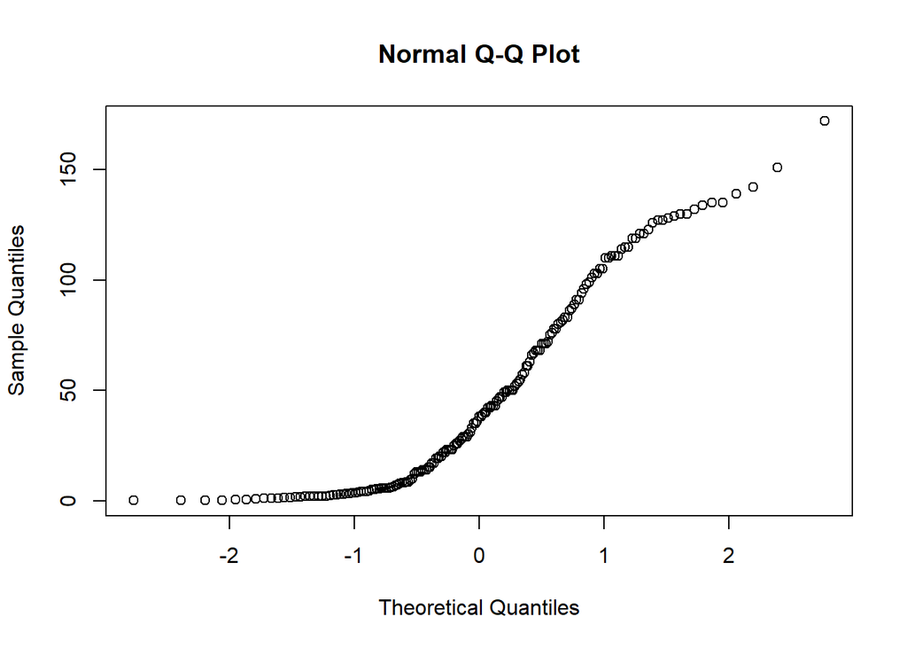

```r
qqnorm(df$Doses.administered.per.100.people)
```

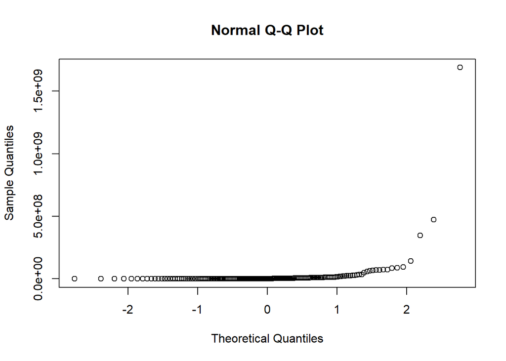

```r
qqnorm(df$Total.doses.administered)
```

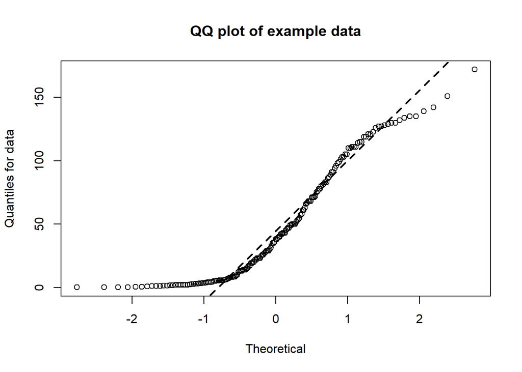

```r
qqnorm(df$Doses.administered.per.100.people,main='QQ plot of example data',xlab='Theoretical',ylab='Quantiles for data')
qqline(df$Doses.administered.per.100.people,lwd=2,lty=2)
```

## can also plot one distribution against another as a quantile-quatile plot using the qqplot() command

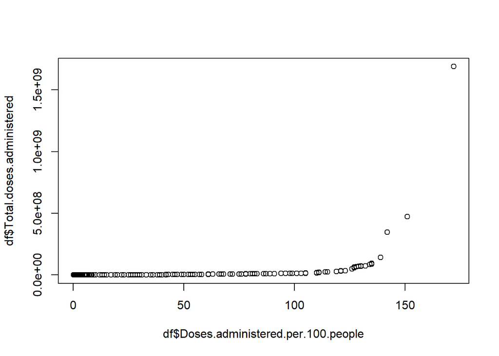

```r
qqplot(df$Doses.administered.per.100.people, df$Total.doses.administered)
```

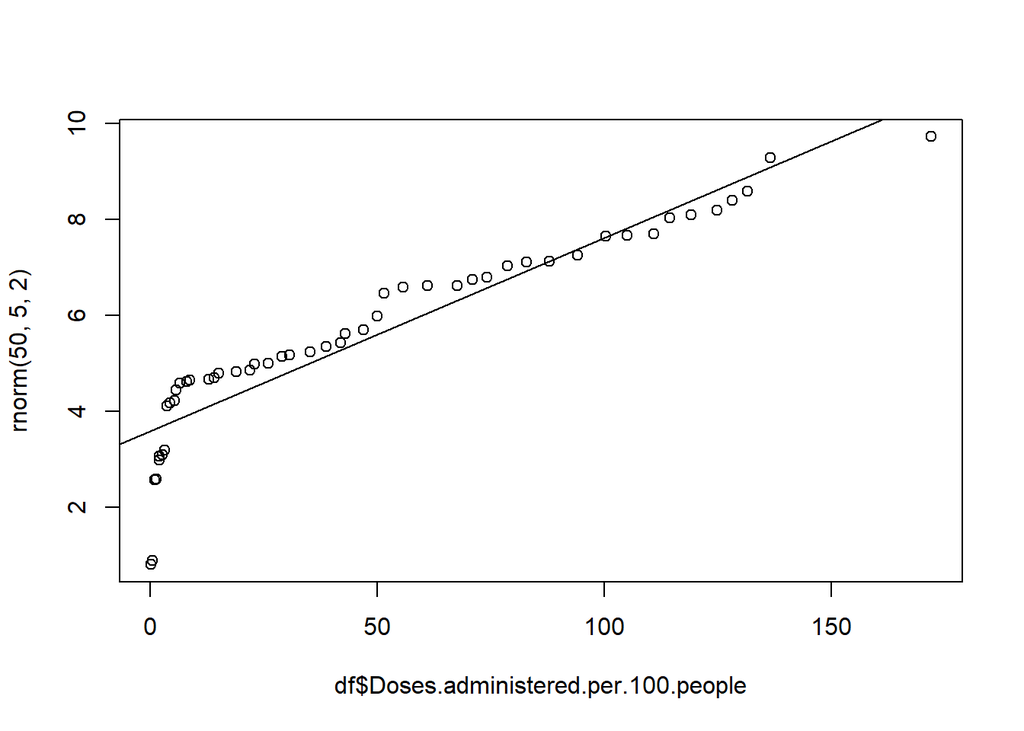

```r
qqp=qqplot(df$Doses.administered.per.100.people,rnorm(50,5,2))
abline(lm(qqp$y ~ qqp$x))
```

## The basic method of applying a t-test is to compare two vectors of numeric data

```r
t.test(df1$Doses.administered.per.100.people, df1$Total.doses.administered)
```

```
##
##  Welch Two Sample t-test
##
## data:  df1$Doses.administered.per.100.people and df1$Total.doses.administered
## t = -2.3435, df = 177, p-value = 0.02021
## alternative hypothesis: true difference in means is not equal to 0
## 95 percent confidence interval:
##  -43415904  -3721443
## sample estimates:
##    mean of x    mean of y
## 4.841629e+01 2.356872e+07
```

## can override the default and use the classic t-test by adding the var.equal = TRUE instruction, which forces the command to assume that the variance of the two samples is equal.

```r
t.test(df$Doses.administered.per.100.people, df$Total.doses.administered, var.equal = TRUE)
```

```
##
##  Two Sample t-test
##
## data:  df$Doses.administered.per.100.people and df$Total.doses.administered
## t = -2.3437, df = 352, p-value = 0.01965
## alternative hypothesis: true difference in means is not equal to 0
## 95 percent confidence interval:
##  -43591689  -3811970
## sample estimates:
##    mean of x    mean of y
## 4.868983e+01 2.370188e+07
```

## can also carry out a one-sample t-test. In this version you supply the name of a single vector and the mean to compare it to (this defaults to 0):

```r
t.test(df$Doses.administered.per.100.people, mu = 5)
```

```
##
##  One Sample t-test
##
## data:  df$Doses.administered.per.100.people
## t = 12.978, df = 176, p-value < 2.2e-16
## alternative hypothesis: true mean is not equal to 5
## 95 percent confidence interval:
##  42.04594 55.33372
## sample estimates:
## mean of x
##  48.68983
```

## Using Directional Hypotheses

```r
t.test(df$Doses.administered.per.100.people, mu = 5, alternative = 'greater')
```

```
##
##  One Sample t-test
##
## data:  df$Doses.administered.per.100.people
## t = 12.978, df = 176, p-value < 2.2e-16
## alternative hypothesis: true mean is greater than 5
## 95 percent confidence interval:
##  43.12314      Inf
## sample estimates:
## mean of x
##  48.68983
```

## Two-Sample U-Test

```r
wilcox.test(df$Doses.administered.per.100.people, df$Total.doses.administered)
```

```
##
##  Wilcoxon rank sum test with continuity correction
##
## data:  df$Doses.administered.per.100.people and df$Total.doses.administered
## W = 0, p-value < 2.2e-16
## alternative hypothesis: true location shift is not equal to 0
```

## Carries out a basic correlation between x and y . If x is a matrix or data frame, y can be omitted

```r
cor(df1$Doses.administered.per.100.people, df1$Total.doses.administered)
```

```
## [1] 0.1759292
```

## Determines covariance between x and y . If x is a matrix or data frame, y can be omitted

```r
x = cov(df1$Doses.administered.per.100.people, df1$Total.doses.administered)
x
```

```
## [1] 1057789362
```

## The cov2cor() command is used to determine the correlation from a matrix of covariance in the following example:

```r
v = as.matrix(x)
cov2cor(v)
```

```
##      [,1]
## [1,]    1
```

## Significance Testing in Correlation Tests

```r
cor.test(df1$Doses.administered.per.100.people, df1$Total.doses.administered)
```

```
##
##  Pearson's product-moment correlation
##
## data:  df1$Doses.administered.per.100.people and df1$Total.doses.administered
## t = 2.3709, df = 176, p-value = 0.01882
## alternative hypothesis: true correlation is not equal to 0
## 95 percent confidence interval:
##  0.02961071 0.31486624
## sample estimates:
##       cor
## 0.1759292
```

## Chi-squared tests of association can be carried out using the chisq.test() command.

```r
chisq.test(df1$Doses.administered.per.100.people)
```

```
##
##  Chi-squared test for given probabilities
##
## data:  df1$Doses.administered.per.100.people
## X-squared = 7340.7, df = 177, p-value < 2.2e-16
```

## Data visulaization using the Basic Boxplot

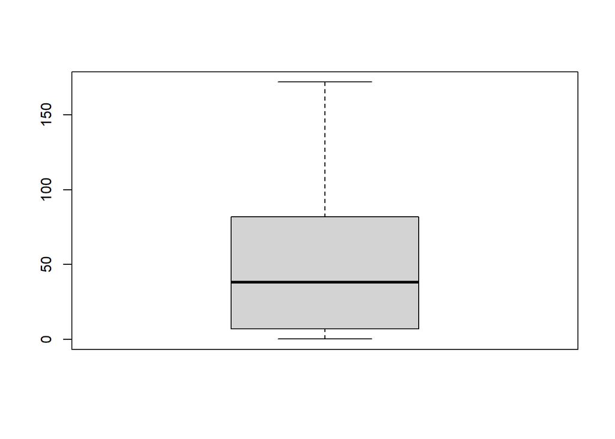

```r
boxplot(df$Doses.administered.per.100.people)
```

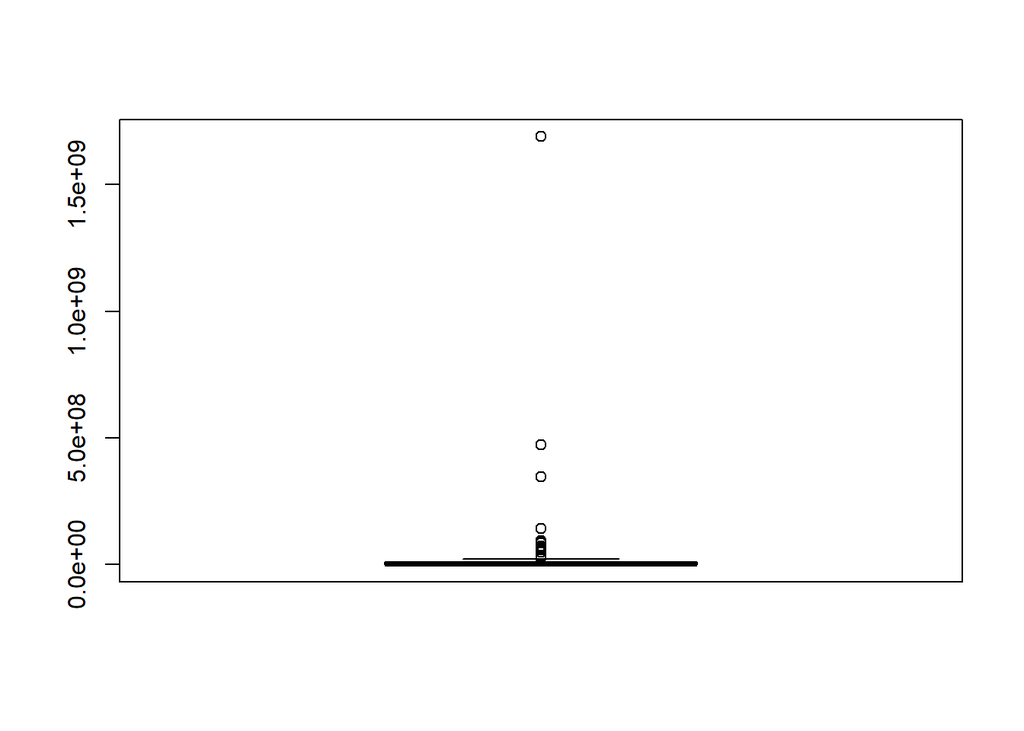

```r
boxplot(df$Total.doses.administered)
```

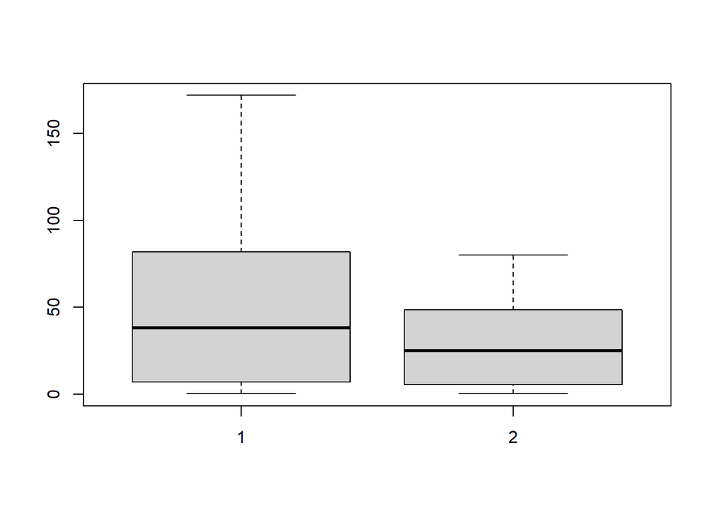

```r
boxplot(df$Doses.administered.per.100.people, df$X..of.population.vaccinated)
```

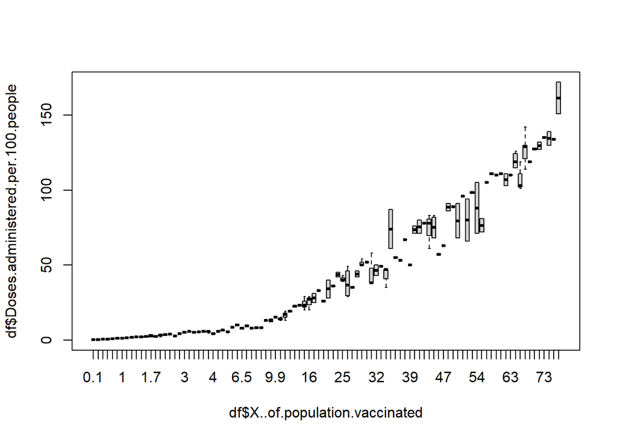

```r
boxplot(df$Doses.administered.per.100.people ~ df$X..of.population.vaccinated,data=df)
```

```r
temp1=head(df)
temp1
```

```
##       Country Doses.administered.per.100.people Total.doses.administered
## 1 Afghanistan                               3.6                  1381416
## 2     Albania                              42.0                  1203087
## 3     Algeria                               7.9                  3421279
## 4      Angola                               5.0                  1592537
## 5   Argentina                              72.0                 32335391
## 6     Armenia                               5.8                   171890
##   X..of.population.vaccinated X..of.population.fully.vaccinated
## 1                         2.0                               0.6
## 2                        24.0                              19.0
## 3                         7.9                               1.7
## 4                         3.0                               2.0
## 5                        56.0                              16.0
## 6                         4.1                               1.7
```

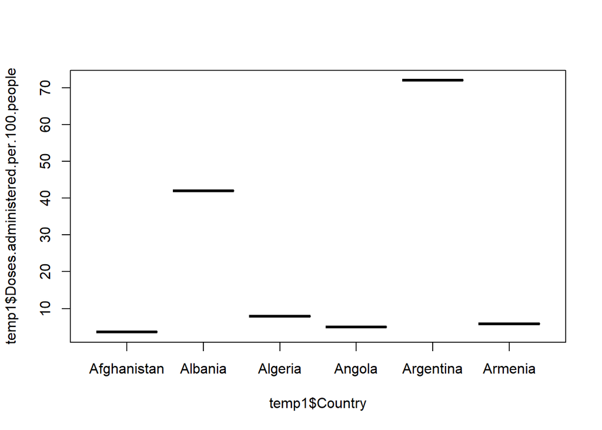

```r
boxplot(temp1$Doses.administered.per.100.people ~ temp1$Country,data=temp1)
```

## Customizing Boxplots

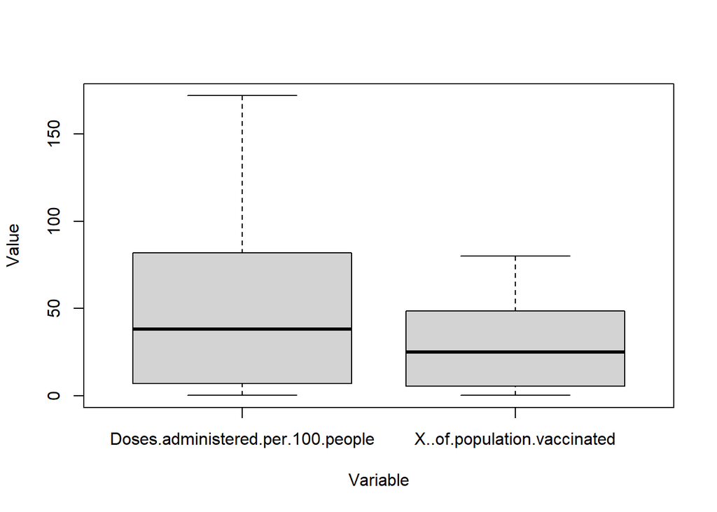

```r
boxplot(df$Doses.administered.per.100.people, df$X..of.population.vaccinated, names = c('Doses.administered.per.100.people', 'X..of.population.vaccinated'))
title(xlab = 'Variable', ylab = 'Value')
```

## horizontal boxplot

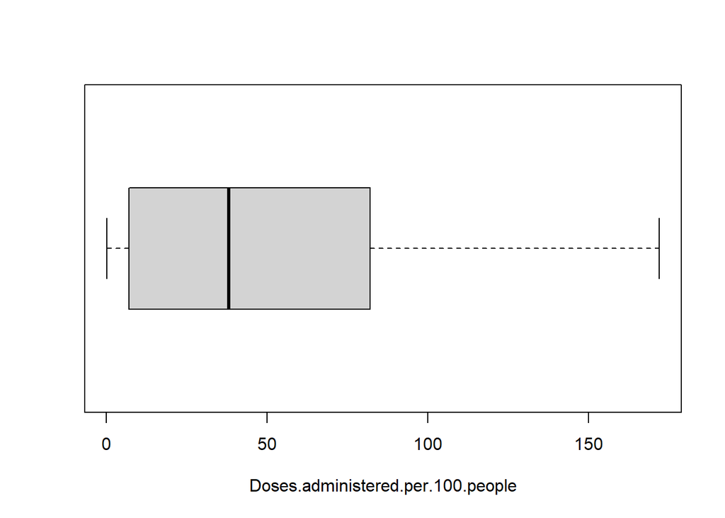

```r
boxplot(df$Doses.administered.per.100.people, horizontal = T)
title(xlab = 'Doses.administered.per.100.people')
```

# Scatter Plots ##Basic Scatter Plots

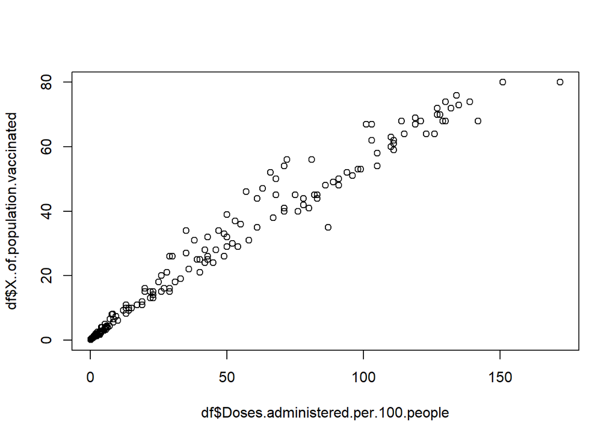

```r
plot(df$Doses.administered.per.100.people, df$X..of.population.vaccinated)
```

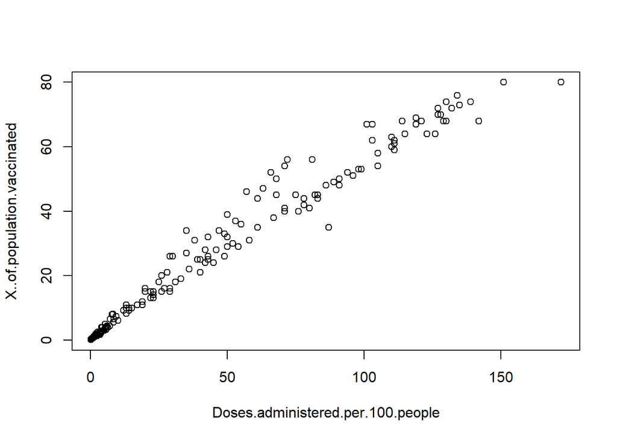

```r
with(df, plot(Doses.administered.per.100.people, X..of.population.vaccinated))
```

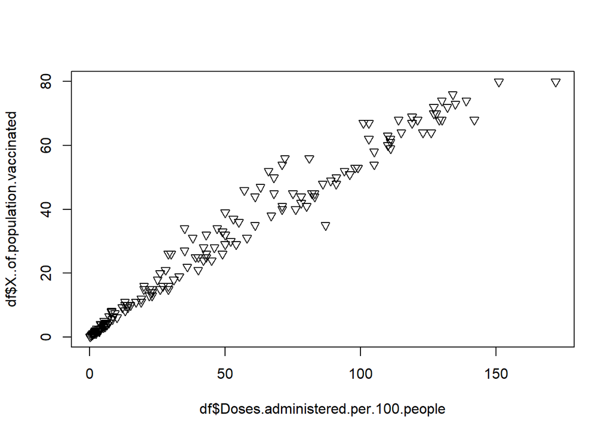

```r
plot(df$Doses.administered.per.100.people, df$X..of.population.vaccinated,pch=25)
```

```r
attach(df)
```

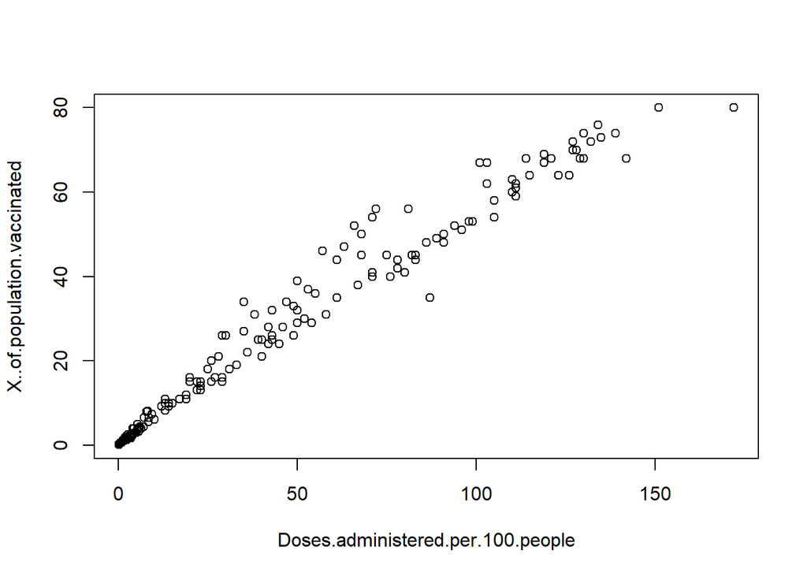

```r
plot(Doses.administered.per.100.people, X..of.population.vaccinated)
```

```r
detach(df)
```

## Adding Axis Labels

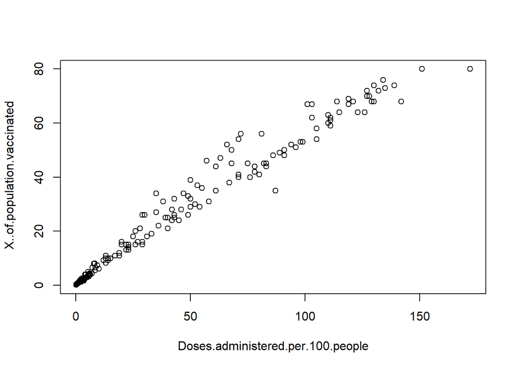

```r
plot(df$Doses.administered.per.100.people, df$X..of.population.vaccinated,xlab = 'Doses.administered.per.100.people', ylab = ' X..of.population.vaccinated')
```

## Plotting Symbols

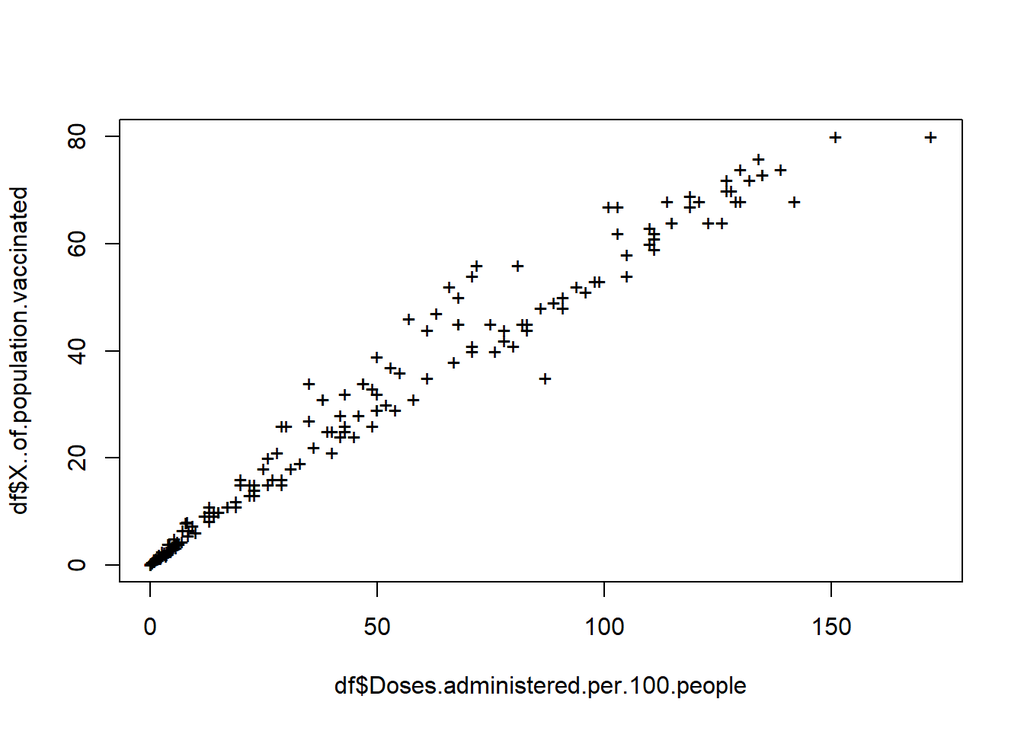

```r
plot(df$Doses.administered.per.100.people, df$X..of.population.vaccinated,pch = "+")
```

## Setting Axis Limits

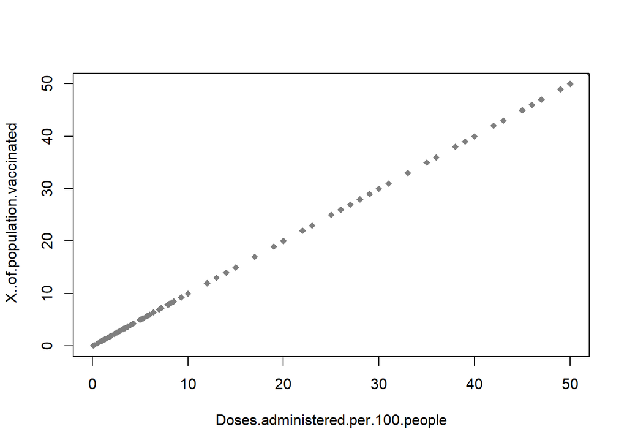

```r
plot(df$Doses.administered.per.100.people, df$Doses.administered.per.100.people,xlab = 'Doses.administered.per.100.people', ylab = ' X..of.population.vaccinated',pch = 18,col = 'gray50', xlim = c(0, 50), ylim = c(0, 50))
```

## combine the previous plot() command with the preceding abline() command

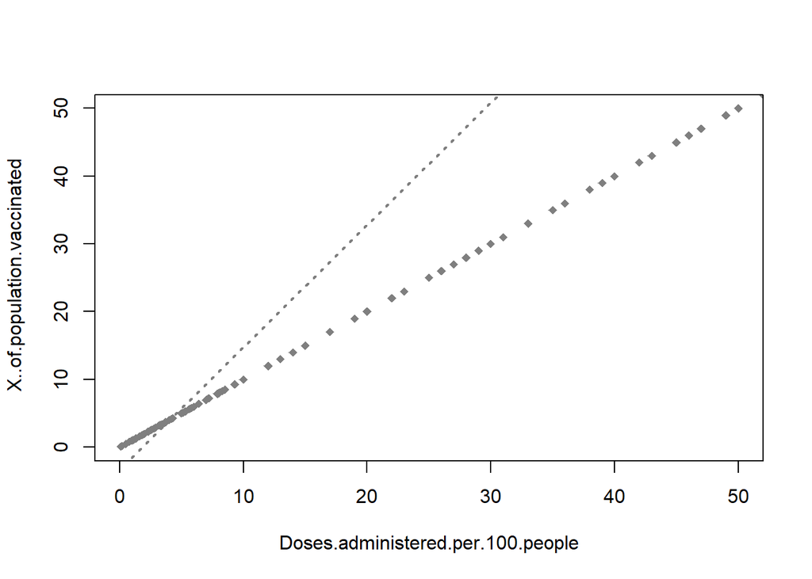

```r
plot(df$Doses.administered.per.100.people, df$Doses.administered.per.100.people,xlab = 'Doses.administered.per.100.people', ylab = ' X..of.population.vaccinated',pch = 18,col = 'gray50', xlim = c(0, 50), ylim = c(0, 50))
abline(lm(Doses.administered.per.100.people ~ X..of.population.vaccinated , data = df), lty = 'dotted', lwd = 2, col = 'gray50')
```

## scatter plot using the ggplot.

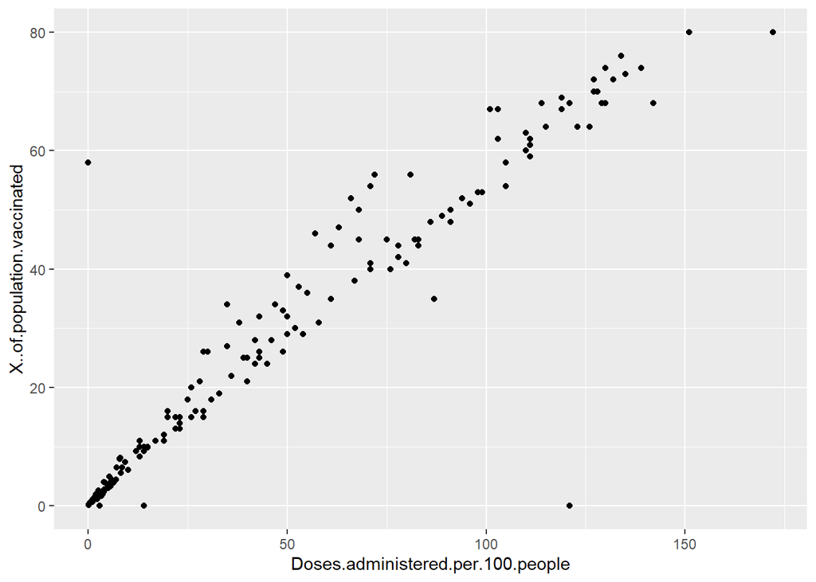

```r
library(ggplot2)
ggplot(df1, aes(x = Doses.administered.per.100.people , y = X..of.population.vaccinated)) +geom_point()
```